# R Notebook

### Atribúty save_percentage.home a save_percentage.away

**charakteristika:** Tento atribút reprezentuje úspešnosť brankára v precentách. Úspešnosť brankára nie je súčasťou pôvodného datasetu - atribút sme si vytvorili a údaje doplnili na základe hodnôt z iných atribútov.

```r
summary(df$save_percentage.home)
```

```
   Min. 1st Qu.  Median    Mean 3rd Qu.    Max.    NA's
 0.5455  0.8696  0.9130  0.9058  0.9487  1.0000      14
```

```r
summary(df$save_percentage.away)
```

```
   Min. 1st Qu.  Median    Mean 3rd Qu.    Max.    NA's
 0.5833  0.8649  0.9070  0.9017  0.9444  1.0000      14
```

Hodnoty úspešnosti brankárov sme vypočítali sami a poskytujú veľmi podobné priemerné hodnoty, ako uvádza oficiálna nHL stránka. Môžeme ale vidieť, že 14 záznamov má tento atribút nevyplnený. Tento problém budeme riešiť pri čistení dát, prípadne následne môŽeme analýzu opätovne vykonať a pozrieť sa či sa niečo nezmení - aj keď vieme, že 14 záznamov je veľmi málo a na celkový výsledok analýzy pravdepodobne budú mať iba veľmi minimálny vplyv.

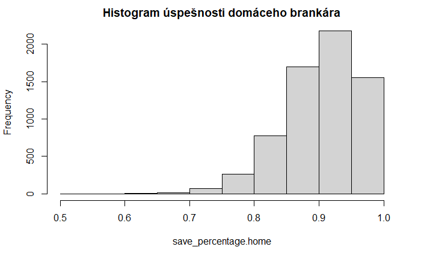

```r
hist(df$save_percentage.home, xlab="save_percentage.home", main="Histogram úspešnosti domáceho brankára")
abline(v = c(mean(df$save_percentage.home),  median(df$save_percentage.home)), col=c("green", "blue"), lty=c(2,3), lwd=c(3,3))
```

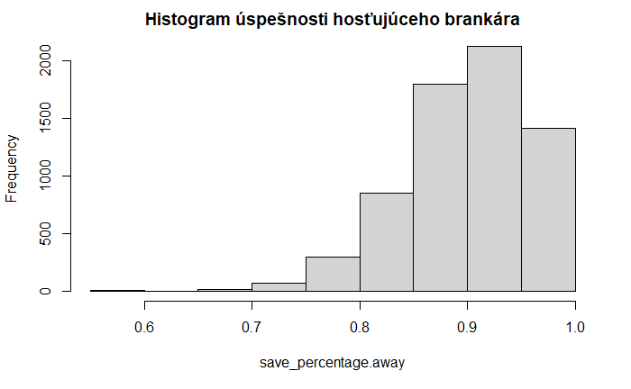

```r
hist(df$save_percentage.away, xlab="save_percentage.away", main="Histogram úspešnosti hosťujúceho brankára")
abline(v = c(mean(df$save_percentage.home),  median(df$save_percentage.home)), col=c("green", "blue"), lty=c(2,3), lwd=c(3,3))
```

Graf nám ukazuje, že hodnoty netvoria normálne rozdelenie. Skôr sú naklonené vľavo s malým počtom vychýlených hodnôt (okolo hodnoty 0.6) - 60% úspešnosť zákrokov je síce naozaj nízka, no jedná sa o reálne hodnoty ktoré sa v NHL a celkovo pri hokeji zriedkavo vysknú.

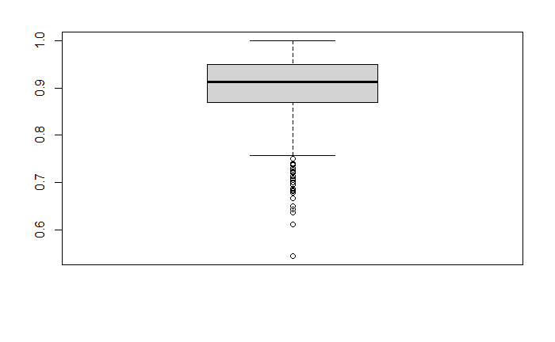

```r
boxplot(df$save_percentage.home)
```

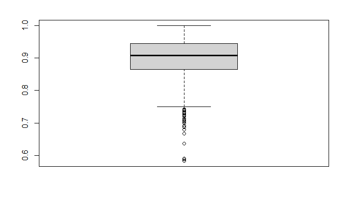

```r
boxplot(df$save_percentage.away)
```

Vychýlené hodnoty sú zo spodného kvantilu a nie je ich veľa. Môžeme sa na ne pozrieť pri čistení dát a zhodnotiť ich úpravu, no tá bude aj vzhľadom na predošlé konštatovanie o reálnom výskyte týchto údajov veľmi nepravdepodobná - predsa len nám tieto hodnoty poskytujú dôležitú štatistickú informáciu o výkone brankárov tímov, ktorú potenciálnou úpravou nechceme stratiť.

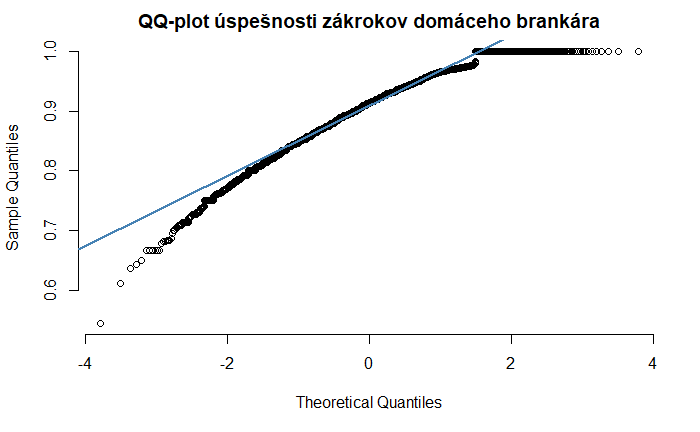

```r
qqnorm(df$save_percentage.home, pch = 1, frame = FALSE, main = "QQ-plot úspešnosti zákrokov domáceho brankára")
qqline(df$save_percentage.home, col = "steelblue", lwd = 2)
```

```
[1] 5994  999
```

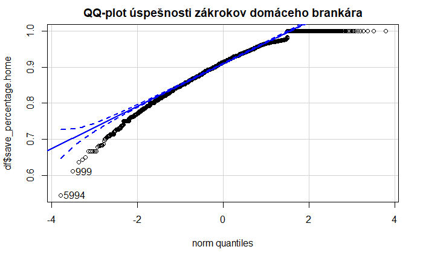

```r
qqPlot(df$save_percentage.home, main = "QQ-plot úspešnosti zákrokov domáceho brankára")
```

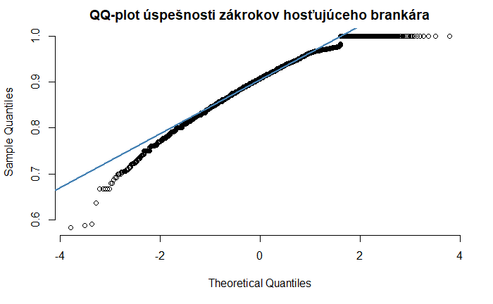

```r
qqnorm(df$save_percentage.away, pch = 1, frame = FALSE,main = "QQ-plot úspešnosti zákrokov hosťujúceho brankára")
qqline(df$save_percentage.away, col = "steelblue", lwd = 2)
```

```
[1] 3937 4578
```

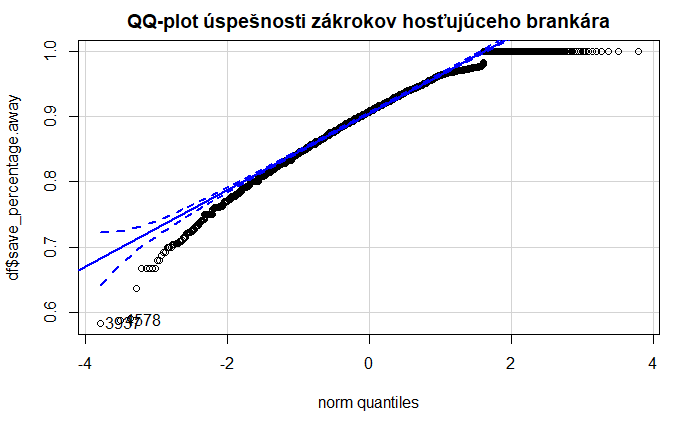

```r
qqPlot(df$save_percentage.away, main = "QQ-plot úspešnosti zákrokov hosťujúceho brankára")
```

Grafy nám ukazujú, že sa nejedná o normálne rozdelenie, pretože vrchné a spodné hodnoty majú vysokú odchylku. Na určitom intervale síce hodnoty pripomínajú normálne rozdelenie (napr. pre **save_percentage.away** aj **save_percentage.home** interval 0.8 až cca 0.96).

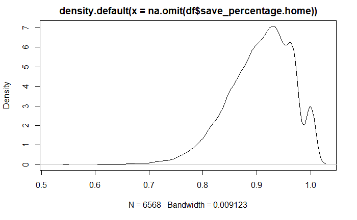

```r
plot(density(na.omit(df$save_percentage.home)))
```

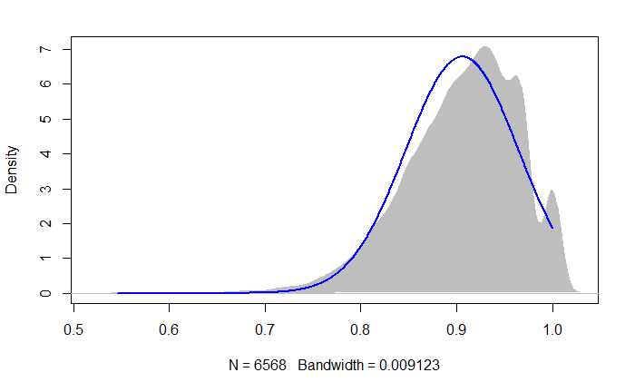

```r
plotNormalDensity(df$save_percentage.home)
```

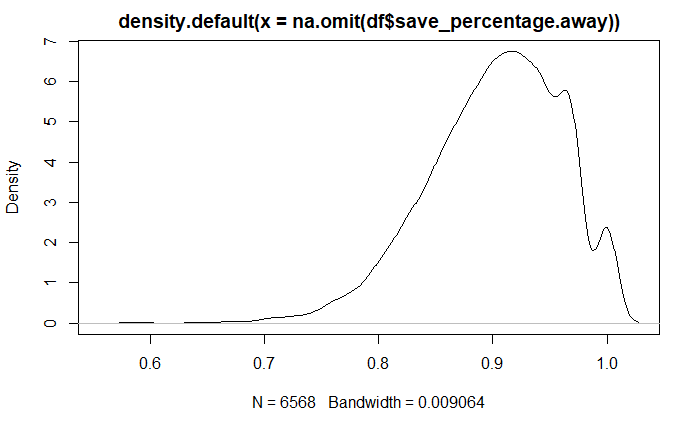

```r
plot(density(na.omit(df$save_percentage.away)))
```

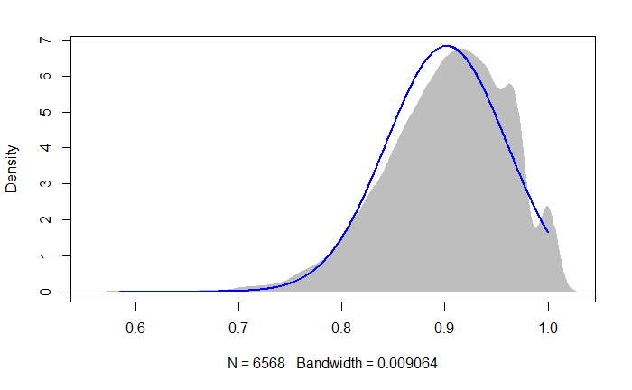

```r
plotNormalDensity(df$save_percentage.away)
```

Grafy hustoty s krivkou normálneho rozdelenia nám ukazujp, že hodnoty sa veľmi podobajú normálnemu rozdeleniu, ale obsahujú viacero lokálnych vrcholov, ktoré sú celkom nezvyčajné.

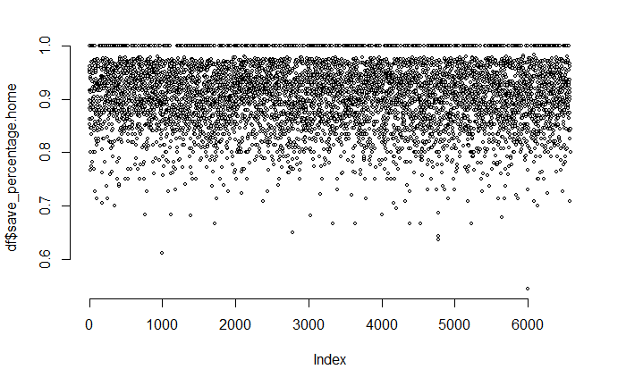

```r
plot(df$save_percentage.home, pch = 21, bg = "lightgray", col = "black", cex = 0.5, frame = FALSE)
```

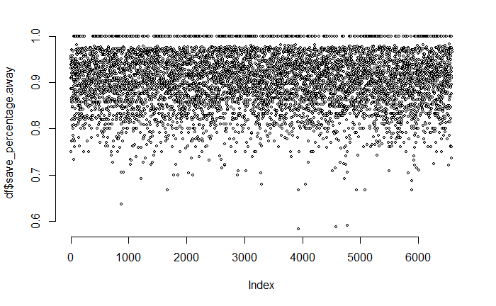

```r
plot(df$save_percentage.away, pch = 21, bg = "lightgray", col = "black", cex = 0.5, frame = FALSE)
```

Graf hustoty hodnôt nám ukazuje, že medzi čístými výkonmi brankárov a inkasovaným aspoň jedným gólom je veľká medzera, čo znamená, že góly padajú aj pri menšom počte striel na bránu. Taktiež v niektorých zápasoch majú brankári veľmi majú percentuálnu úspešnosť, čo môže byť spôsobené napríklad zranením pri zákroku (alebo veľmi zlým dňom pre brankára), z ktorého padol gól. Medzera medzi 100% úspešnosťou a zvyšnými hodnotami je spôsobená aj počtom striel - pokiaľ brankár inkasuje gól a má mať percentuálnu úspešnosť veľmi blízku číslu 100, muselo by naňho v zápase byť vystrelených naozaj veľa striel - preto sa väčšinou percentuálne úspešnosti pri najlepších brankároch pohybujú “iba” okolo hodnoty 96%. 99% pravdepodobnosť je preto takmer nereálna.

Test normality nebude potrebný, keďže grafy jednoznačne ukazujú, že distribúcia atribútov **save_percentage** nebude pochádzať z normálneho rozdelenie ale z rozdelenia s distribúciou naklonenou vľavo.

```r
skewness(df$save_percentage.home)
```

```
[1] NA
```

```r
skewness(df$save_percentage.away)
```

```
[1] NA
```

Šikmosť nie je možné vypočítať, keďźe atribút ešte obsahuje NA hodnoty. Tie budú odstranené pri čistení dát.

Zhrnutie: Atribúty **save_percentage.home** a **save_percentage.away** sú spojité atribúty reprezentujúceho percentuálnu úspešnosť brankára (vyjadrené pomocou desatin. čísla), ktoré majú distribúciu naklonenú vĺavo.

## Párová analýza

V tejto časti chceme identifikovať možné vzťahy medzi jednotlivými atribútmi prostredníctvom výpočtu korelácií, respektíve korelačnej matice. Nakoľko niektoré atribúty obsahujú nenumerické hodnoty, pre prvotnú identifikáciu možných vzťahov medzi atribútmi použijeme iba atribúty s numerickými hodnotami. Čo sa týka nenumerických atribútov **won.home** a **won.away**, tie aktuálne obsahujú pravdivostné hodnoty TRUE alebo FALSe a teda ich môžeme zmeniť na numerické (nahradením TRUE za 1 a FALSE za 0).

```r
df$won.home[df$won.home == "TRUE"] <- "1"
df$won.home[df$won.home == "FALSE"] <- "0"
df$won.away[df$won.away == "TRUE"] <- "1"
df$won.away[df$won.away == "FALSE"] <- "0"
class(df$won.home) = "numeric"
class(df$won.away) = "numeric"
unique(df$won.home)
```

```
[1] 1 0
```

```r
unique(df$won.away)
```

```
[1] 0 1
```

Pre vytvorenie korelačnej matice potrebujeme numerické atribúty. Vytvoríme si pomocný dataset, ktorý bude obsahovať iba numerické atribúty pôvodného datasetu.

```r
df_numeric <- subset(df, select=-c(type, abbreviation.away, settled_in, abbreviation.home))
sapply(df_numeric, is.numeric)
```

```
                     season                  goals.away                  goals.home
                       TRUE                        TRUE                        TRUE
               team_id.away                    won.away                  shots.away
                       TRUE                        TRUE                        TRUE
                  hits.away                    pim.away powerPlayOpportunities.away
                       TRUE                        TRUE                        TRUE
        powerPlayGoals.away   faceOffWinPercentage.away              giveaways.away
                       TRUE                        TRUE                        TRUE
             takeaways.away                blocked.away                team_id.home
                       TRUE                        TRUE                        TRUE
                   won.home                  shots.home                   hits.home
                       TRUE                        TRUE                        TRUE
                   pim.home powerPlayOpportunities.home         powerPlayGoals.home
                       TRUE                        TRUE                        TRUE
  faceOffWinPercentage.home              giveaways.home              takeaways.home
                       TRUE                        TRUE                        TRUE
               blocked.home        save_percentage.home        save_percentage.away
                       TRUE                        TRUE                        TRUE
```

Z výpisu vyššie môžeme vidieť, že všetky atribúty pomocného datasetu **df_numeric** sú numerické. Môžeme vytvoriť korelačnú maticu.

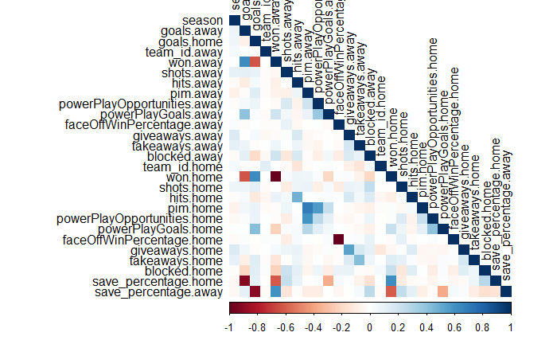

```r
corrplot(cor(df_numeric, use="complete.obs"), type="lower", method="color", tl.col="black")
```

Z korelačnej matice môžeme vidieť, že najväčšia korelácia (záporná) je medzi atribútmi **won.home** a **won.away**, čo je pochopiteľné, pretože keď jeden tím vyhrá, druhý musí prehrať. Podobné záporné korelácie môžeme vidieť medzi atribútmi **faceOffWinPercentage.home** a **faceOffWinPercentage.away**, ktoré hovoria o vyhratých vhadzovaniach. Tiež si môžeme všimnúť vysoké korelácie medzi atribútmi **save_percentage.home** a **goals.away**, **save_percentage.home** a **won.away** alebo **save_percentage.home** a **won.home** (podobne aj pre atribút **save_percentage.away** s niektorými atribútmi domáceho tímu). Tieto korelácie značia napríklad o tom ako úspešnoť brankára domáceho tímu ovplyvňuje počet gólov hosťujúceho tímu alebo jeho šancu na výhru (podobne to platí aj naopak). Ďalšie korelácie sú medzi atribútmi **won.home** a **goals.home**:

```r
cor(df$save_percentage.away, df$goals.home)
```

```
[1] NA
```

```r
cor(df$save_percentage.away, df$won.home)
```

```
[1] NA
```

```r
cor(df$save_percentage.home, df$goals.away)
```

```
[1] NA
```

```r
cor(df$save_percentage.home, df$won.away)
```

```
[1] NA
```

```r
cor(df$won.home, df$goals.home)
```

```
[1] 0.6289938
```

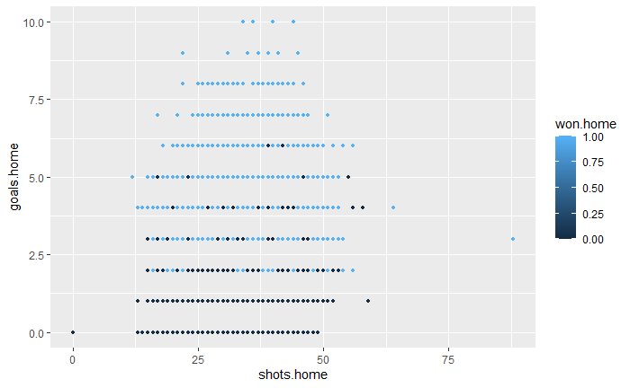

```r
ggplot(df, aes(x=shots.home, y=goals.home, color=won.home)) + geom_point(size=1)
```

Korelácia týchto dvoch atribútov je tiež logická. Môžeme z nej vyvodiť, že čím viac gólov tím strelí, tým je väčšia šanca, že zápas vyhrá. Podobne to platí aj pre atribúty **won.away** a **goals.away**:

```r
cor(df$won.away, df$goals.away)
```

```
[1] 0.6295663
```

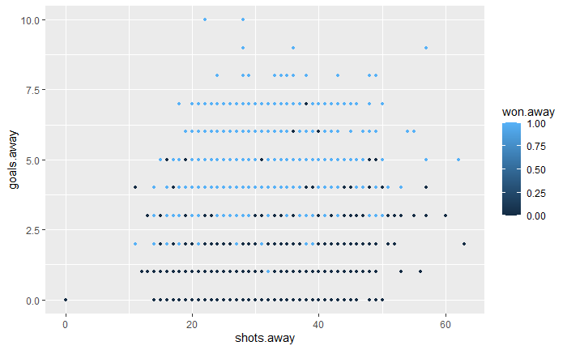

```r
ggplot(df, aes(x=shots.away, y=goals.away, color=won.away)) + geom_point(size=1)
```

Rovnako môžeme sledovať aj koreláciu medzi atribútmi **won.away** a **goals.home** alebo **won.home** a **goals.away**. V tomto prípade však budú korelácie záporné:

```r
cor(df$won.away, df$goals.home)
```

```
[1] -0.6216961
```

```r
cor(df$won.home, df$goals.away)
```

```
[1] -0.6221667
```

Ďalšiu koreláciu môžeme pozorovať medzi atribútmi **pim.home** a **pim.away**. Atribúty hovoria o trestných minutách tímov. Určitá korelácia je pochopiteľná, pretože ak sa napríklad dvaja hráči pobijú, idú obaja na trestnú lavičku. V takomto prípade dostávajú trestné minúty oba tíma zároveň, čoho dôsledkom je zvýšená korelácia týchto atribútov. Atribúty však obsahujú N/A hodnoty, takže ich pre znázornenie korelácie budeme ignorovať.

```r
cor(df$pim.home, df$pim.away, use="complete.obs")
```

```
[1] 0.6993652
```

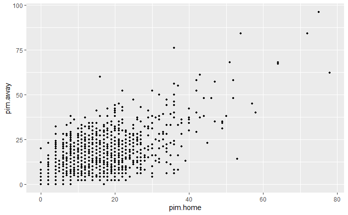

```r
ggplot(df, aes(x=pim.home, y=pim.away)) + geom_point(size=1)
```

Trestné minúty jedného tímu znamenajú presilovku druhého tímu. Z toho tiež vyplýva korelácia medzi atribútmi **pim.home** s **powerPlayOpportunities.away** a naopak **pim.away** a **powerPlayOpportunities.home**:

```r
cor(df$pim.home, df$powerPlayOpportunities.away, use="complete.obs")
```

```
[1] 0.5669678
```

```r
cor(df$pim.away, df$powerPlayOpportunities.home, use="complete.obs")
```

```
[1] 0.5926063
```

Z vyššie uvedených korelácií medzi jednotlivými atribútmi môžeme vytvoriť určité pracovné hypotézy, ktoré budeme v ďalších fázach projektu overovať.

Vhodné by bolo zobraziť aj úspešnosť brankárov pomocou grafov, ale nie je to zatiaľ možné, pretože atribút obsahuje aj iné/nenumerické hodnoty - NaN. Tento problém plánujeme vyriešiť pri čistení dát, po ktorom môžeme vykonať novú analýzu tohoto atribútu.

## Čistenie a úprava dát

V tejto kapitole sa venujeme čisteniu a úprave dát. Niektoré úpravy sme však spravili už pred analýzou. Tieto úpravy, ako napríklad deduplikáciu dát, bolo potrebné spraviť hneď na začiatku projektu, pretože sa týkali vytvárania datasetu, ktorý v projekte používame. Dataset sme vytvorili spojením 3 tabuliek. Okrem deduplikácie dát sme tiež odstránili niektoré atribúty a iné sme naopak pridali, respektíve vytvorili (ako napríklad vytvorenie atribútu úspešnosti brankára, ktorá sa počíta na základe gólov a striel oponenta). Cieľom tejto kapitoly je, aby všetky záznamy obsahovali údaje pre všetky atribúty. Je teda potrebné odstrániť všetky N/A hodnoty. Z analýzy atribútu **type** vieme, že náš dataset obsahuje výsledky niektorých zápasov, ktoré nespadajú do súťaže NHL. Pre začiatok sa pozrieme, aké atribúty obsahujú N/A hodnoty a následne odstránime dané zápasy, ktoré nepatria do NHL (takéto zápasy majú hodnotu atribútu **type** rovnú ‘A’).

V tejto sekcii sa teda sústredíme najmä na náhradu NA hodnôt, elimináciu zbytočných záznamov (bez štatistického prínosu), normalizáciu vychýlených hodnôt identifikovaných pri prieskumnej analýze a na záver transformácii formátu niektorých atribútov (z reťazcov na numerické hodnoty) prostredníctvom tzv. one-hot encoding.

Po odstránení N/A hodnôt budeme môcť odstrániť vychýlené hodnoty atribútov **shots.home**, **pim.home**, **pim.away** a **blocked.away** využitím horného kvantilu.

Ako prvé skontrolujeme, ktoré všetky atribúty obsahujú N/A hodnoty.

```r
cbind(lapply(lapply(df, is.na), sum))
```

```
                            [,1]
season                      0
type                        0
goals.away                  0
goals.home                  0
team_id.away                0
won.away                    0
shots.away                  4
hits.away                   4
pim.away                    4
powerPlayOpportunities.away 4
powerPlayGoals.away         4
faceOffWinPercentage.away   4
giveaways.away              4
takeaways.away              4
blocked.away                4
abbreviation.away           5
team_id.home                0
won.home                    0
settled_in                  0
shots.home                  4
hits.home                   4
pim.home                    4
powerPlayOpportunities.home 4
powerPlayGoals.home         4
faceOffWinPercentage.home   4
giveaways.home              4
takeaways.home              4
blocked.home                4
abbreviation.home           5
save_percentage.home        14
save_percentage.away        14
```

Ako bolo spomenuté, niektoré zápasy napatria do súťaže NHL. Niektoré atribúty môžu obsahovať N/A hodnoty práve z tohto dôvodu. Najskôr odstránime spomínané zápasy.

```r
table(df$type)
```

```
   A    P    R
   5  481 6096
```

```r
df = df[!(df$type == 'A')]
table(df$type)
```

```
   P    R
 481 6096
```

Ako môžeme vidieť z výpisu vyššie, dataset už neobsahuje žiade zápasy, ktoré by mali hodnotu atribútu **type** rovnú ‘A’. Teraz sa pozrieme, či to nejakým spôsobom ovplyvnilo počet N/A hodnôt ostatných atribútov.

```r
cbind(lapply(lapply(df, is.na), sum))
```

```
                            [,1]
season                      0
type                        0
goals.away                  0
goals.home                  0
team_id.away                0
won.away                    0
shots.away                  4
hits.away                   4
pim.away                    4
powerPlayOpportunities.away 4
powerPlayGoals.away         4
faceOffWinPercentage.away   4
giveaways.away              4
takeaways.away              4
blocked.away                4
abbreviation.away           0
team_id.home                0
won.home                    0
settled_in                  0
shots.home                  4
hits.home                   4
pim.home                    4
powerPlayOpportunities.home 4
powerPlayGoals.home         4
faceOffWinPercentage.home   4
giveaways.home              4
takeaways.home              4
blocked.home                4
abbreviation.home           0
save_percentage.home        14
save_percentage.away        14
```

Môžeme si všimnúť, že zmizli všetky N/A hodnoty atribútov **abbrevation.away** a **abbreviation.home**. Teraz začneme postupne prechádzať ostatné atribúty obsahujúce N/A hodnoty, pričom navrhneme spôsob akým ich nahradíme.

```r
df[is.na(df$shots.away)]
```

| season | type | goals.away | goals.home | team_id.away | won.away | shots.away | hits.away | pim.away | powerPlayOpportunities.away | powerPlayGoals.away | faceOffWinPercentage.away | giveaways.away | takeaways.away | blocked.away | abbreviation.away | team_id.home | won.home | settled_in | shots.home | hits.home | pim.home | powerPlayOpportunities.home | powerPlayGoals.home | faceOffWinPercentage.home | giveaways.home | takeaways.home | blocked.home | abbreviation.home | save_percentage.home | … |
| --- | --- | --- | --- | --- | --- | --- | --- | --- | --- | --- | --- | --- | --- | --- | --- | --- | --- | --- | --- | --- | --- | --- | --- | --- | --- | --- | --- | --- | --- | --- |
| 20172018 | P | 0 | 0 | 28 | 0 | NA | NA | NA | NA | NA | NA | NA | NA | NA | SJS | 24 | 0 | tbc | NA | NA | NA | NA | NA | NA | NA | NA | NA | ANA | NA | … |
| 20172018 | P | 0 | 0 | 52 | 0 | NA | NA | NA | NA | NA | NA | NA | NA | NA | WPG | 54 | 0 | tbc | NA | NA | NA | NA | NA | NA | NA | NA | NA | VGK | NA | … |
| 20172018 | P | 0 | 0 | 54 | 0 | NA | NA | NA | NA | NA | NA | NA | NA | NA | VGK | 52 | 0 | tbc | NA | NA | NA | NA | NA | NA | NA | NA | NA | WPG | NA | … |
| 20162017 | P | 0 | 0 | 3 | 0 | NA | NA | NA | NA | NA | NA | NA | NA | NA | NYR | 9 | 0 | tbc | NA | NA | NA | NA | NA | NA | NA | NA | NA | OTT | NA | … |

Z výpisu záznamov, ktoré obsahujú N/A hodnotu v atribúte **shots_away** si môžeme všimnúť, že aj ďalšie atribúty majú N/A hodnoty. Môžeme predpokladať, že všetky N/A hodnoty (okrem atribútov **save_percentage.home** a **save_percentage.away**) v našom datasete sú obsiahnuté v práve týchto 4 konkrétnych zápasoch. Vypíšeme si čísla tímov jednotlivých atribútov, ktoré obsahujú N/A hodnoty. Ak sa čísla tímov budú zhodovať, znamená to, že všetky N/A hodnoty sú obsiahnuté v spomínaných 4 zápasoch.

```r
df$team_id.away[is.na(df$shots.away)]
```

```
[1] 28 52 54  3
```

```r
df$team_id.away[is.na(df$hits.away)]
```

```
[1] 28 52 54  3
```

```r
df$team_id.away[is.na(df$pim.away)]
```

```
[1] 28 52 54  3
```

```r
df$team_id.away[is.na(df$powerPlayOpportunities.away)]
```

```
[1] 28 52 54  3
```

```r
df$team_id.away[is.na(df$powerPlayGoals.away)]
```

```
[1] 28 52 54  3
```

```r
df$team_id.away[is.na(df$faceOffWinPercentage.away)]
```

```
[1] 28 52 54  3
```

```r
df$team_id.away[is.na(df$giveaways.away)]
```

```
[1] 28 52 54  3
```

```r
df$team_id.away[is.na(df$takeaways.away)]
```

```
[1] 28 52 54  3
```

```r
df$team_id.away[is.na(df$blocked.away)]
```

```
[1] 28 52 54  3
```

```r
df$team_id.away[is.na(df$shots.home)]
```

```
[1] 28 52 54  3
```

```r
df$team_id.away[is.na(df$hits.home)]
```

```
[1] 28 52 54  3
```

```r
df$team_id.away[is.na(df$pim.home)]
```

```
[1] 28 52 54  3
```

```r
df$team_id.away[is.na(df$powerPlayOpportunities.home)]
```

```
[1] 28 52 54  3
```

```r
df$team_id.away[is.na(df$powerPlayGoals.home)]
```

```
[1] 28 52 54  3
```

```r
df$team_id.away[is.na(df$faceOffWinPercentage.home)]
```

```
[1] 28 52 54  3
```

```r
df$team_id.away[is.na(df$giveaways.home)]
```

```
[1] 28 52 54  3
```

```r
df$team_id.away[is.na(df$takeaways.home)]
```

```
[1] 28 52 54  3
```

```r
df$team_id.away[is.na(df$blocked.home)]
```

```
[1] 28 52 54  3
```

```r
df$team_id.home[is.na(df$shots.away)]
```

```
[1] 24 54 52  9
```

```r
df$team_id.home[is.na(df$hits.away)]
```

```
[1] 24 54 52  9
```

```r
df$team_id.home[is.na(df$pim.away)]
```

```
[1] 24 54 52  9
```

```r
df$team_id.home[is.na(df$powerPlayOpportunities.away)]
```

```
[1] 24 54 52  9
```

```r
df$team_id.home[is.na(df$powerPlayGoals.away)]
```

```
[1] 24 54 52  9
```

```r
df$team_id.home[is.na(df$faceOffWinPercentage.away)]
```

```
[1] 24 54 52  9
```

```r
df$team_id.home[is.na(df$giveaways.away)]
```

```
[1] 24 54 52  9
```

```r
df$team_id.home[is.na(df$takeaways.away)]
```

```
[1] 24 54 52  9
```

```r
df$team_id.home[is.na(df$blocked.away)]
```

```
[1] 24 54 52  9
```

```r
df$team_id.home[is.na(df$shots.home)]
```

```
[1] 24 54 52  9
```

```r
df$team_id.home[is.na(df$hits.home)]
```

```
[1] 24 54 52  9
```

```r
df$team_id.home[is.na(df$pim.home)]
```

```
[1] 24 54 52  9
```

```r
df$team_id.home[is.na(df$powerPlayOpportunities.home)]
```

```
[1] 24 54 52  9
```

```r
df$team_id.home[is.na(df$powerPlayGoals.home)]
```

```
[1] 24 54 52  9
```

```r
df$team_id.home[is.na(df$faceOffWinPercentage.home)]
```

```
[1] 24 54 52  9
```

```r
df$team_id.home[is.na(df$giveaways.home)]
```

```
[1] 24 54 52  9
```

```r
df$team_id.home[is.na(df$takeaways.home)]
```

```
[1] 24 54 52  9
```

```r
df$team_id.home[is.na(df$blocked.home)]
```

```
[1] 24 54 52  9
```

Z výpisov môžeme vidieť, že sa čísla tímov pre všetky atribúty obsahujúce N/A hodnoty opakujú. Z toho vyplýva, že všetky N/A hodnoty v našom datasete sú z práve týchto 4 konkrétnych zápasov. Tieto zápasy pre nás teda nemajú žiadny prínos, pretože im chýbajú hodnoty veľkého množstva atribútov. Z tohto dôvodu nebudeme N/A hodnoty nijakým spôsobom nahrádzať a záznamy o daných zápasoch z datesetu jednoducho vymažeme.

```r
df = df[!(is.na(df$shots.away))]
cbind(lapply(lapply(df, is.na), sum))
```

```
                            [,1]
season                      0
type                        0
goals.away                  0
goals.home                  0
team_id.away                0
won.away                    0
shots.away                  0
hits.away                   0
pim.away                    0
powerPlayOpportunities.away 0
powerPlayGoals.away         0
faceOffWinPercentage.away   0
giveaways.away              0
takeaways.away              0
blocked.away                0
abbreviation.away           0
team_id.home                0
won.home                    0
settled_in                  0
shots.home                  0
hits.home                   0
pim.home                    0
powerPlayOpportunities.home 0
powerPlayGoals.home         0
faceOffWinPercentage.home   0
giveaways.home              0
takeaways.home              0
blocked.home                0
abbreviation.home           0
save_percentage.home        10
save_percentage.away        10
```

Ako môžeme vidieť z výpisu vyššie, po odstránení záznamov, ktoré obsahujú N/A hodnoty v atribúte **shots.away**, zmizli všetky N/A hodnoty z celého datasetu okrem atribútov **save_percentage.home** a **save_percentage.away**. Teraz skontrolujeme tieto dva atribúty.

```r
df[is.na(df$save_percentage.away)]
```

| season | type | goals.away | goals.home | team_id.away | won.away | shots.away | hits.away | pim.away | powerPlayOpportunities.away | powerPlayGoals.away | faceOffWinPercentage.away | giveaways.away | takeaways.away | blocked.away | abbreviation.away | team_id.home | won.home | settled_in | shots.home | hits.home | pim.home | powerPlayOpportunities.home | powerPlayGoals.home | faceOffWinPercentage.home | giveaways.home | takeaways.home | blocked.home | abbreviation.home | save_percentage.home | … |
| --- | --- | --- | --- | --- | --- | --- | --- | --- | --- | --- | --- | --- | --- | --- | --- | --- | --- | --- | --- | --- | --- | --- | --- | --- | --- | --- | --- | --- | --- | --- |
| 20172018 | P | 0 | 0 | 28 | 0 | 0 | 0 | 0 | 0 | 0 | 0 | 0 | 0 | 0 | SJS | 54 | 0 | tbc | 0 | 0 | 0 | 0 | 0 | 0 | 0 | 0 | 0 | VGK | NaN | … |
| 20172018 | P | 0 | 0 | 26 | 0 | 0 | 0 | 0 | 0 | 0 | 0 | 0 | 0 | 0 | LAK | 54 | 0 | tbc | 0 | 0 | 0 | 0 | 0 | 0 | 0 | 0 | 0 | VGK | NaN | … |
| 20172018 | P | 0 | 0 | 54 | 0 | 0 | 0 | 0 | 0 | 0 | 0 | 0 | 0 | 0 | VGK | 15 | 0 | tbc | 0 | 0 | 0 | 0 | 0 | 0 | 0 | 0 | 0 | WSH | NaN | … |
| 20172018 | P | 0 | 0 | 15 | 0 | 0 | 0 | 0 | 0 | 0 | 0 | 0 | 0 | 0 | WSH | 54 | 0 | tbc | 0 | 0 | 0 | 0 | 0 | 0 | 0 | 0 | 0 | VGK | NaN | … |
| 20172018 | P | 0 | 0 | 5 | 0 | 0 | 0 | 0 | 0 | 0 | 0 | 0 | 0 | 0 | PIT | 15 | 0 | tbc | 0 | 0 | 0 | 0 | 0 | 0 | 0 | 0 | 0 | WSH | NaN | … |
| 20162017 | P | 0 | 0 | 20 | 0 | 0 | 0 | 0 | 0 | 0 | 0 | 0 | 0 | 0 | CGY | 24 | 0 | tbc | 0 | 0 | 0 | 0 | 0 | 0 | 0 | 0 | 0 | ANA | NaN | … |
| 20162017 | P | 0 | 0 | 10 | 0 | 0 | 0 | 0 | 0 | 0 | 0 | 0 | 0 | 0 | TOR | 15 | 0 | tbc | 0 | 0 | 0 | 0 | 0 | 0 | 0 | 0 | 0 | WSH | NaN | … |
| 20162017 | P | 0 | 0 | 18 | 0 | 0 | 0 | 0 | 0 | 0 | 0 | 0 | 0 | 0 | NSH | 24 | 0 | tbc | 0 | 0 | 0 | 0 | 0 | 0 | 0 | 0 | 0 | ANA | NaN | … |
| 20162017 | P | 0 | 0 | 18 | 0 | 0 | 0 | 0 | 0 | 0 | 0 | 0 | 0 | 0 | NSH | 5 | 0 | tbc | 0 | 0 | 0 | 0 | 0 | 0 | 0 | 0 | 0 | PIT | NaN | … |
| 20162017 | P | 0 | 0 | 18 | 0 | 0 | 0 | 0 | 0 | 0 | 0 | 0 | 0 | 0 | NSH | 16 | 0 | tbc | 0 | 0 | 0 | 0 | 0 | 0 | 0 | 0 | 0 | CHI | NaN | … |

Z výpisu vyššie môžeme vidieť, že 10 N/A hodnôt v **save_percentage.home** je pri rovnakých zápasoch ako pri atribúte **save_percentage.away**. Tiež si môžeme všimnúť, že tieto hodnoty vznikli z dôvodu delenia nulou (pri výpočte save_percentage vyhádzame z rozdielu počtu striel a počtu gólov, pričom výsledok ešte delíme počtom striel, t. j. v prípade, že počet striel je 0, výsledkom je NaN, pretože nulou nedelíme). Tiež si môžeme všimnúť, že všetky ostatné atribúty v týchto zápasoch majú hodnotu 0. Aj keby sme nahradili save_percentage 100-percentnou úspešnosťou, nemali by nás tieto zápasy žiadnu výpovednú hodnotu. Tieto zápasy teda môžeme odstrániť.

```r
df = df[!(is.na(df$save_percentage.away))]
```

Po odstránení spomínaných zápasov overíme, že dataset už neobsahuje žiadne N/A hodnoty.

```r
cbind(lapply(lapply(df, is.na), sum))
```

```
                            [,1]
season                      0
type                        0
goals.away                  0
goals.home                  0
team_id.away                0
won.away                    0
shots.away                  0
hits.away                   0
pim.away                    0
powerPlayOpportunities.away 0
powerPlayGoals.away         0
faceOffWinPercentage.away   0
giveaways.away              0
takeaways.away              0
blocked.away                0
abbreviation.away           0
team_id.home                0
won.home                    0
settled_in                  0
shots.home                  0
hits.home                   0
pim.home                    0
powerPlayOpportunities.home 0
powerPlayGoals.home         0
faceOffWinPercentage.home   0
giveaways.home              0
takeaways.home              0
blocked.home                0
abbreviation.home           0
save_percentage.home        0
save_percentage.away        0
```

Ako môžeme vidieť z výpisu vyššie, dataset už neobsahuje žiadne N/A hodnoty. Môžeme teda prejsť na odstraňovanie vychýlených atribútov **shots.home**, **pim.home**, **pim.away** a **blocked.away**.

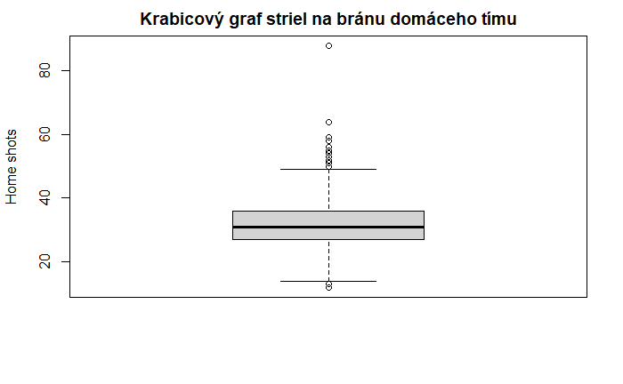

```r
boxplot(df$shots.home, ylab="Home shots", xlab="", main="Krabicový graf striel na bránu domáceho tímu")
```

Vychýlenú hodnotu nahradíme 75% kvantilom počtu striel domácich tímov v zápasoch, ktoré sa dohrali v predĺžení.

```r
df$shots.home[df$shots.home > 70] = quantile(df$shots.home[df$settled_in == 'OT'], 0.75)
```

Teraz skontrolujeme, či sa vychýlená hodnota nahradila.

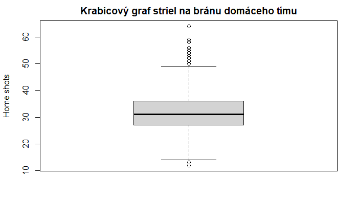

```r
boxplot(df$shots.home, ylab="Home shots", xlab="", main="Krabicový graf striel na bránu domáceho tímu")
```

Na krabicovom grafe vyššie môžeme vidieť, že sme vychýlenú hodnotu zrazili. Podobným spôsobom nahradíme aj vychýlené hodnoty vo zvyšných atribútoch.

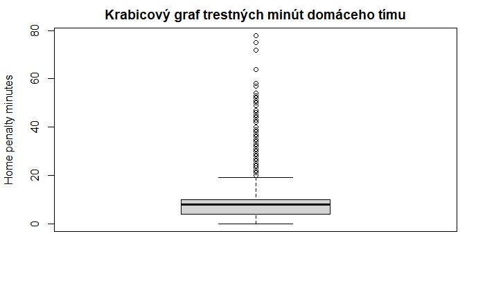

```r
boxplot(df$pim.home, ylab="Home penalty minutes", xlab="", main="Krabicový graf trestných minút domáceho tímu")
```

V prípade atribútu **pim.home** odstránime hodnoty väčšie ako 60.

```r
df$pim.home[df$pim.home > 60] = quantile(df$pim.home, 0.75)
```

Odstránenie hodnôt skontrolujeme.

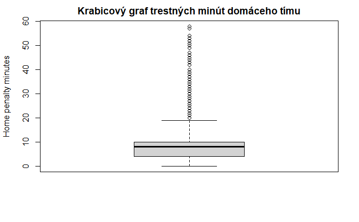

```r
boxplot(df$pim.home, ylab="Home penalty minutes", xlab="", main="Krabicový graf trestných minút domáceho tímu")
```

Môžeme vidieť, že atribút **pim.home** už neobsahuje hodnoty väčšie ako 60.

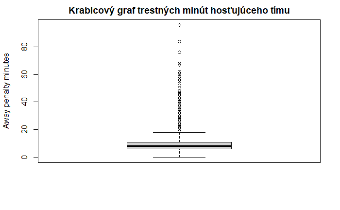

```r
boxplot(df$pim.away, ylab="Away penalty minutes", xlab="", main="Krabicový graf trestných minút hosťujúceho tímu")
```

Podobne ako pri **pim.home** odstránime aj vychýlené hodnoty atribútu **pim.away** (tiež hodnoty väčšie ako 60) a hodnoty tohto atribútu následne skontrolujeme.

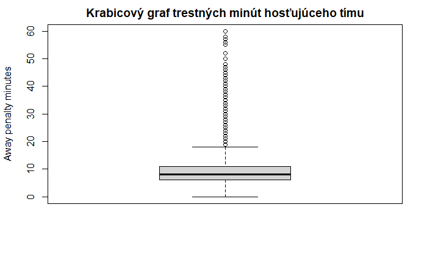

```r
df$pim.away[df$pim.away > 60] = quantile(df$pim.away, 0.75)
boxplot(df$pim.away, ylab="Away penalty minutes", xlab="", main="Krabicový graf trestných minút hosťujúceho tímu")
```

Posledným atribútom s vychýlenými hodnotami je atribút **blocked.away**. Aj v tomto prípade odstránime hodnoty väčšie ako 60 použitím horného kvantilu. Nakoniec hodnoty opät skontrolujeme pomocou krabicového grafu.

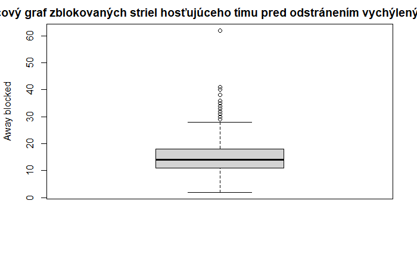

```r
boxplot(df$blocked.away, ylab="Away blocked", xlab="", main="Krabicový graf zblokovaných striel hosťujúceho tímu pred odstránením vychýlených hodnôt")
```

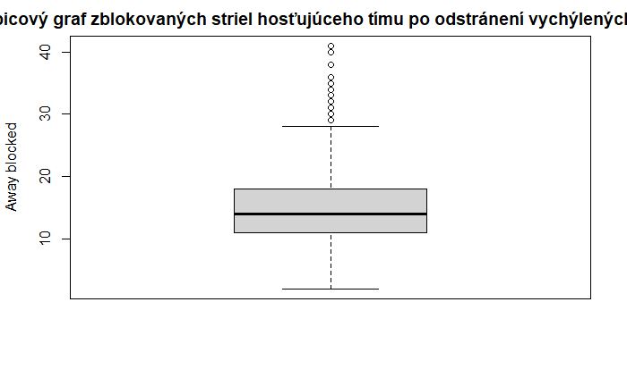

```r
df$blocked.away[df$blocked.away > 60] = quantile(df$blocked.away, 0.75)

boxplot(df$blocked.away, ylab="Away blocked", xlab="", main="Krabicový graf zblokovaných striel hosťujúceho tímu po odstránení vychýlených hodnôt")
```

### Príprava dát pre tréningový a trénovací dataset

V rámci čistenia dát je potrebné pripraviť dataset, aby bolo možné použiť ho pre strojové učenie, zhlukovú analýzu a Bayesovú štatistiku, pričom treba dataset rozdeliť na tréningový a testovací. Aby bolo možné ho použiť pre tieto účely, je potrebné, aby mal numerické dáta. Náš dataset obsahuje 4 nenumerické atribúty: **type**, **settled_in**, **abbreviation.home** a **abbreviation.away**. Atribúty abbreviation nie sú zo štatistického hľadiska dôležité, sú to len skratky jednotlivých tímov. Atribúty **type** a **settled_in** však hovoria o type zápasu (či bol zápas v rámci regulárnej sezóny alebo v rámci vyraďovacej časti) a či bol zápas ukončený v riadnom hracom čase alebo v predĺžení. Oba atribúty teda nadobúdajú práve dve hodnoty a môžeme ich zmeniť na numerické (0 alebo 1). Ako prvé zmeníme atribúty **type**:

```r
unique(df$type)
```

```
[1] "R" "P"
```

Ako môžeme vidieť, atribút **type** obsahuje dve hodnoty - “R”, ak bol zápas odohraný v rámci regulárnej sezóny, alebo “P”, ak bol zápas odohraný v rámci vyraďovacej časti. Tento atribút môžeme nahradiť za **isPlayOff**, pričom tento atribút bude obsahovať hodnotu 0, ak bol zápas odohraný v rámci sezóny (teda pre hodnoty “R”) a 1, ak bol odohraný v rámci vyraďovacej časti (teda pre hodnoty “P”).

```r
df$isPlayOff <- ifelse(df$type == "P", 1, 0)
```

Po nahradení môžeme skontrolovať, či boli hodnoty dosadené správne.

```r
unique(df$isPlayOff[df$type == "R"])
```

```
[1] 0
```

```r
unique(df$isPlayOff[df$type == "P"])
```

```
[1] 1
```

Môžeme vidieť, že pre hodnoty “R” sme dosadili do atribútu **isPlayOff** hodnoty 0, a pre “P” hodnoty 1. Teraz môžeme atribút **type** odstrániť.

```r
df <- subset(df, select=-c(type))
df
```

| season | goals.away | goals.home | team_id.away | won.away | shots.away | hits.away | pim.away | powerPlayOpportunities.away | powerPlayGoals.away | faceOffWinPercentage.away | giveaways.away | takeaways.away | blocked.away | abbreviation.away | team_id.home | won.home | settled_in | shots.home | hits.home | pim.home | powerPlayOpportunities.home | powerPlayGoals.home | faceOffWinPercentage.home | giveaways.home | takeaways.home | blocked.home | abbreviation.home | save_percentage.home | save_percentage.away | … |
| --- | --- | --- | --- | --- | --- | --- | --- | --- | --- | --- | --- | --- | --- | --- | --- | --- | --- | --- | --- | --- | --- | --- | --- | --- | --- | --- | --- | --- | --- | --- |
| 20162017 | 4 | 7 | 4 | 0 | 27 | 30 | 6 | 4 | 2 | 50.9 | 12 | 9 | 11 | PHI | 16 | 1 | REG | 28 | 20 | 8 | 3 | 2 | 49.1 | 16 | 8 | 9 | CHI | 0.8519 | 0.7500 | … |
| 20172018 | 4 | 3 | 24 | 1 | 34 | 16 | 6 | 3 | 1 | 43.8 | 7 | 4 | 14 | ANA | 7 | 0 | OT | 33 | 17 | 8 | 2 | 1 | 56.2 | 5 | 6 | 14 | BUF | 0.8824 | 0.9091 | … |
| 20152016 | 4 | 1 | 21 | 1 | 29 | 17 | 9 | 3 | 1 | 45.7 | 13 | 5 | 20 | COL | 52 | 0 | REG | 21 | 22 | 11 | 2 | 0 | 54.3 | 13 | 7 | 9 | WPG | 0.8621 | 0.9524 | … |
| 20152016 | 1 | 2 | 52 | 0 | 21 | 21 | 10 | 4 | 0 | 31.4 | 4 | 14 | 16 | WPG | 12 | 1 | REG | 29 | 16 | 8 | 5 | 2 | 68.6 | 12 | 11 | 13 | CAR | 0.9524 | 0.9310 | … |
| 20172018 | 1 | 2 | 20 | 0 | 23 | 20 | 19 | 3 | 0 | 54.7 | 10 | 4 | 7 | CGY | 24 | 1 | REG | 41 | 15 | 13 | 6 | 1 | 45.3 | 13 | 4 | 21 | ANA | 0.9565 | 0.9512 | … |
| 20162017 | 4 | 1 | 15 | 1 | 39 | 19 | 8 | 2 | 1 | 46.6 | 8 | 5 | 24 | WSH | 8 | 0 | REG | 23 | 27 | 4 | 4 | 1 | 53.4 | 12 | 7 | 18 | MTL | 0.8974 | 0.9565 | … |
| 20152016 | 1 | 2 | 10 | 0 | 26 | 24 | 19 | 4 | 1 | 56.9 | 6 | 2 | 7 | TOR | 26 | 1 | REG | 41 | 23 | 10 | 2 | 0 | 43.1 | 12 | 2 | 14 | LAK | 0.9615 | 0.9512 | … |
| 20172018 | 1 | 4 | 23 | 0 | 20 | 11 | 27 | 5 | 0 | 47.5 | 13 | 5 | 15 | VAN | 24 | 1 | REG | 35 | 10 | 15 | 6 | 3 | 52.5 | 11 | 6 | 12 | ANA | 0.9500 | 0.8857 | … |
| 20172018 | 0 | 2 | 29 | 0 | 34 | 12 | 8 | 3 | 0 | 57.6 | 3 | 8 | 14 | CBJ | 21 | 1 | REG | 32 | 20 | 8 | 3 | 1 | 42.4 | 5 | 5 | 13 | COL | 1.0000 | 0.9375 | … |
| 20152016 | 3 | 2 | 22 | 1 | 36 | 31 | 8 | 4 | 1 | 50.6 | 5 | 2 | 17 | EDM | 5 | 0 | OT | 41 | 36 | 8 | 4 | 1 | 49.4 | 10 | 5 | 12 | PIT | 0.9167 | 0.9512 | … |

[output cut: 990 more lines]

Podobným spôsobom odstránime aj atribút **settled_in**. Najskôr skontrolujeme, aké hodnoty nadobúda.

```r
unique(df$settled_in)
```

```
[1] "REG" "OT"
```

Na základe nadobúdaných hodnôt môžeme opäť vytvoriť nový atribút **isOverTime**, pričom tento atribút bude mať hodnotu 1 pre “OT” v atribúte **settled_in** a 0 pre “REG”.

```r
df$isOverTime <- ifelse(df$settled_in == "OT", 1, 0)
```

Opäť skontrolujeme dosadenie hodnôt do nového atribútu.

```r
unique(df$isOverTime[df$settled_in == "REG"])
```

```
[1] 0
```

```r
unique(df$isOverTime[df$settled_in == "OT"])
```

```
[1] 1
```

Hodnoty boli dosadené správne a teda môžeme atribút **settled_in** vymazať.

```r
df <- subset(df, select=-c(settled_in))
df
```

| season | goals.away | goals.home | team_id.away | won.away | shots.away | hits.away | pim.away | powerPlayOpportunities.away | powerPlayGoals.away | faceOffWinPercentage.away | giveaways.away | takeaways.away | blocked.away | abbreviation.away | team_id.home | won.home | shots.home | hits.home | pim.home | powerPlayOpportunities.home | powerPlayGoals.home | faceOffWinPercentage.home | giveaways.home | takeaways.home | blocked.home | abbreviation.home | save_percentage.home | save_percentage.away | isPlayOff | … |
| --- | --- | --- | --- | --- | --- | --- | --- | --- | --- | --- | --- | --- | --- | --- | --- | --- | --- | --- | --- | --- | --- | --- | --- | --- | --- | --- | --- | --- | --- | --- |
| 20162017 | 4 | 7 | 4 | 0 | 27 | 30 | 6 | 4 | 2 | 50.9 | 12 | 9 | 11 | PHI | 16 | 1 | 28 | 20 | 8 | 3 | 2 | 49.1 | 16 | 8 | 9 | CHI | 0.8519 | 0.7500 | 0 | … |
| 20172018 | 4 | 3 | 24 | 1 | 34 | 16 | 6 | 3 | 1 | 43.8 | 7 | 4 | 14 | ANA | 7 | 0 | 33 | 17 | 8 | 2 | 1 | 56.2 | 5 | 6 | 14 | BUF | 0.8824 | 0.9091 | 0 | … |
| 20152016 | 4 | 1 | 21 | 1 | 29 | 17 | 9 | 3 | 1 | 45.7 | 13 | 5 | 20 | COL | 52 | 0 | 21 | 22 | 11 | 2 | 0 | 54.3 | 13 | 7 | 9 | WPG | 0.8621 | 0.9524 | 0 | … |
| 20152016 | 1 | 2 | 52 | 0 | 21 | 21 | 10 | 4 | 0 | 31.4 | 4 | 14 | 16 | WPG | 12 | 1 | 29 | 16 | 8 | 5 | 2 | 68.6 | 12 | 11 | 13 | CAR | 0.9524 | 0.9310 | 0 | … |
| 20172018 | 1 | 2 | 20 | 0 | 23 | 20 | 19 | 3 | 0 | 54.7 | 10 | 4 | 7 | CGY | 24 | 1 | 41 | 15 | 13 | 6 | 1 | 45.3 | 13 | 4 | 21 | ANA | 0.9565 | 0.9512 | 0 | … |
| 20162017 | 4 | 1 | 15 | 1 | 39 | 19 | 8 | 2 | 1 | 46.6 | 8 | 5 | 24 | WSH | 8 | 0 | 23 | 27 | 4 | 4 | 1 | 53.4 | 12 | 7 | 18 | MTL | 0.8974 | 0.9565 | 0 | … |
| 20152016 | 1 | 2 | 10 | 0 | 26 | 24 | 19 | 4 | 1 | 56.9 | 6 | 2 | 7 | TOR | 26 | 1 | 41 | 23 | 10 | 2 | 0 | 43.1 | 12 | 2 | 14 | LAK | 0.9615 | 0.9512 | 0 | … |
| 20172018 | 1 | 4 | 23 | 0 | 20 | 11 | 27 | 5 | 0 | 47.5 | 13 | 5 | 15 | VAN | 24 | 1 | 35 | 10 | 15 | 6 | 3 | 52.5 | 11 | 6 | 12 | ANA | 0.9500 | 0.8857 | 0 | … |
| 20172018 | 0 | 2 | 29 | 0 | 34 | 12 | 8 | 3 | 0 | 57.6 | 3 | 8 | 14 | CBJ | 21 | 1 | 32 | 20 | 8 | 3 | 1 | 42.4 | 5 | 5 | 13 | COL | 1.0000 | 0.9375 | 0 | … |
| 20152016 | 3 | 2 | 22 | 1 | 36 | 31 | 8 | 4 | 1 | 50.6 | 5 | 2 | 17 | EDM | 5 | 0 | 41 | 36 | 8 | 4 | 1 | 49.4 | 10 | 5 | 12 | PIT | 0.9167 | 0.9512 | 0 | … |

[output cut: 990 more lines]

Fázu čistenia dát môžeme ukončiť vytvorením trénovacieho a testovacieho datasetu. Rozhodli sme rozdeliť dataset na základe sezón, pričom trénovací dataset budú tvoriť 4 sezóny a testovací dataset jedna (posledná) sezóna. Percentuálne tento pomer vychádza na približne 80%:20%.

```r
df_train = df[!(df$season == "20192020")]
df_test = df[df$season == "20192020"]
nrow(df_train)
```

```
[1] 5351
```

```r
nrow(df_test)
```

```
[1] 1212
```